# Decoding from different representational systems: A simulation

Ven Popov

2016-11-09

*This is an old draft and my thinking and simulations have evolved, do not distribute*

In a recent paper, Fernandino et al. (2016) demonstrated nicely that the identity of individual concepts can be decoded from higher-level non-modality specific brain regions in thegGeneral semantic network (GSN; Binder et al, 2009) based on their sensory-motor features. In the study, participants performed a concreteness judgement task (“Can it be experienced with the senses?”) on 600 concrete and 300 abstract words for which sound, color, shape, manipulability, and visual motion ratings were available (ranging on a 7-point Likert scale from “not at all important” to “very important” for the concept’s meaning). A forward-encoding model based on these sensory-motor ratings was used to predict activation patterns related to individual words in the following procedure: First, generalized least-squares multiple regression was used on a training set of 850 words such that the model learned to map between the weightings of the five attributes and voxel-wise brain activity in the ROIs. Then, for the remaining 50 words activity patterns were predicted on the basis of the learned mappings and compared to the observed patterns of all 50 test words using correlation percentile ranks as accuracy measure. This procedure was repeated on 6 different training and test sets, 3 of which consistent of concrete words and the remaining 3 of abstract words.

The main finding was that the forward-model predicted brain activity patterns for concrete words, but not for abstract words, above chance-level in the semantic network ROIs (61% mean accuracy), but not in a set of control regions associated with visual word form processing. Thus, sensory-motor information was useful in discriminating between individual word meanings in the GSN. Fernandino et al. (2016) suggested that high-level heteromodal brain regions may integrate afferent information from modality-specific sensory areas to build multimodal conceptual representations that reflect their sensory-motor attributes (as proposed by Fernandino et al., 2016b).

While this is a striking finding, the fact that conceptual information in the GSN can be decoded from sensory-motor features, does not necessarily mean that the representational code used in the GSN is sensory-motor in nature. Amodal representations can be consistent with the results if it is granted that these representations are associated with corresponding sensory-motor activity in modal-specific areas (Mahon, 2015). Mahon has previously argued that activation of sensory-motor areas during comprehension can be accounted by a top-down activation and exchange of information from amodal representations. It is plausible to extend this argument in that the successful decoding of conceptual identity in the GSN based on sensory-motor features might reflect a correlation between amodal representations in the GSN and sensory-motor representations elsewhere in the brain.

In order to demonstrate that this is the case here I present a simulation in which the identity of decimal numbers is decoded by their binary representations through a proeedure very similar to the one Fernandino et al. (2016) used. Before I do that, however, it is important to clear up a few points when it comes arbitrary vs systematic mappings. There are at least three ways in which mappings between representations can be made.

### Completely arbitrary mappings between sets

We have a completely arbitrary mapping between two representational systems, when the mapping from one item to the other is entirely unrelated to the mappings between other items from the two systems. Such is the mapping between the geographical locations of countries and their names, between the meaning of words and their length, etc. Basically, and arbitrary mapping between to sets $A = {A_1, A_2, ..., A_n}$ and $B = {B_1, B_2, ..., B_n}$ has to be explicitely expressed independently for each member:

$A_1 \mapsto B_1 \\ A_2 \mapsto B_2\\ ...\\ A_n \mapsto B_n$

With arbitrary mapping systems, knowledge of the mapping of any subset of the items cannot predict the mapping between any other items. While such mappings are not implausible in the brain and can be implemented in pattern associator given that the patterns are orthogonal to each other, they are obviously incosistent with Fernandino et al (2016) results.

### Systematic mappings between sets that use the same representational code

Fernandino et al. (2016) argument is that since the identity of individual concepts can be predicted in the GSN based on their sensory-motor features, then the GSN is using multimodal sensory-motor representations. That is, the representations in the GSN and lower-level processing areas are not only related, but they use the same representational code, namely, a sensory-motor code.

An example of such mappings between sets that use the same representational system, that can serve as an analogy, is the set of multi-digit numbers {10,11,12,…,3491,…} and the 9 digits in the decimal systems {0,1,2,3,4,5,6,7,8,9}. Both use the same representational code to represent quantities, the decimal system, and there’s a systematic mapping from the simple “sensory” features (the digits) to the “multimodal” representations (the numbers):

$$\overline{d_nd_{n-1}d_{n-2}...d_2d_0} = \sum_{i=0}^n (d_i \cdot 10^{i})\\
3491 = 3\cdot1000 + 4\cdot100 + 9\cdot10 + 1\cdot1$$

The mapping between the two systems is not only systematic, but they also use the same representational code. Because the mapping is systematic, knowledge of the mapping procedure is enough to predict the mapping between members of the two sets.

### Systematic mapping between sets that use different representational code

There is third alternative to the two previous relations between sets, that is also consistent with Fernandino et al. results. Two sets can use different representational codes, while maintaining a systematic mapping between the two that allows you to predict the mapping of any one pair of items from the mappings of the others. Within the context of the brain and Fernandino et al. study, the GSN and the sensory-motor cortices might use completely different representational codes, while still having a systemating mapping beween representations in each.

A prime example, is the relation between the decimal and the binary systems for representing numbers. A binary number can be transformed into a decimal by the following formula:

$$(\overline{d_nd_{n-1}d_{n-2}...d_2d_0})_{2} = \Big(\sum_{i=0}^n (d_i \cdot 2^{i})\Big)_{10}\\
101011_2 = 1\cdot2^5 + 0\cdot2^4 + 1\cdot2^3 + 0\cdot2^2 + 1\cdot2^1 + 1\cdot2^0 = 32_{10}+8_{10}+2_{10} + 1_{10} = 43_{10}$$

It is clear, that there is a systematic mapping between the decimal and the binary system and that these two system use different codes to represent numbers. The question is, would be able to predict a binary represented number (analogous to the pattern of activaiton in the GSN in Fernandino et al., 2016) from the features of its decimal representation (analogous to the sensory-motor features of the concepts in Fernandino et al., 2016)?

In the simulation below I demonstrate that this is indeed the case and I argue by analogy that decoding of conceptual identity in the GSN based on sensory-motor features is not necessarily evidence of an underlying multimodal sensory-motor representational code in the GSN.

## Decoding a decimal number representation from its binary features: A simulation

### Representations and correspondense to Fernandino et al. (2016)

For the current simulation I will use decimal numbers from 0 to 99999, represented as vectors of length 5. For example, the number 3497 will be represented decimally as [0 3 4 9 7]. This representation is analogous to the five sensory motor features ratings for each word in Fernandino et al (2016) study. The binary representation of this number is [0 0 0 0 0 0 0 0 0 0 0 0 0 0 0 0 0 0 0 0 1 1 0 1 1 0 1 0 1 0 0 1], where the length of the vector is 17, because the largest decimal number in the set, 99999, has a 17 digits in its binary format. The binary representation would be analogous to the BOLD activation pattern in the GSN.

### Modelling procedure

The procedure for predicting the number identity (aka concept identity) of witheld numbers, from their binary features (aka brain activation), based on a forward model of the decimal features (aka the sensory-motor ratings) will be almost identical to the one used by Fernandino et al. (2016). I will use Fernandino et al. (2016) terminology of predicted maps (PMs) and observed maps (OMs).

#### *Data*

Let’s define functions for data generation and generate the relevant representations.

```r
# converts a decimal number to a binary number
dec2bin = function(number, noBits=32) {
  binary_vector = rev(as.numeric(intToBits(number)))
  if(missing(noBits)) {
    return(binary_vector)
  } else {
    binary_vector[-(1:(length(binary_vector) - noBits))]
  }
}

# converts a number to a vector of digits
num2vect <- function(number, noBits) {
  aschar <- as.character(number)
  vector <- as.numeric(unlist(strsplit(aschar,'')))
  vector <- c(rep(0, noBits-length(vector)), vector)
  return(vector)
}
```

Using these two functions, we generate 100,000 items, the numbers from 0 to 99,999 and transform them into decimal and binary vectors.

```r
items <- 0:99999
nDecFeat <- max(nchar(items))
nBinFeat <- 33-which(dec2bin(max(items))==1)[1]


numbers <- cbind(items,
                 t(sapply(items, num2vect, noBits=nDecFeat)),
                 t(sapply(items, dec2bin, noBits=nBinFeat)))
numbers <- as.data.frame(numbers)
names(numbers) <- c('item', paste0('d',1:5), paste0('b',1:17))
```

Here’s what the data that we are going to feed into the model looks like. These are the decimal vectors (columns d1 to d5; sensory features) and the binary vectors (b1 to b17; bold activation) for a sample of random numbers (items; concepts).

```r
idx <- sample(items, 10)
print(numbers[idx,], row.names=FALSE)
```

```
##   item d1 d2 d3 d4 d5 b1 b2 b3 b4 b5 b6 b7 b8 b9 b10 b11 b12 b13 b14 b15 b16 b17
##  67552  6  7  5  5  2  1  0  0  0  0  0  1  1  1   1   1   1   0   0   0   0   0
##  87774  8  7  7  7  4  1  0  1  0  1  0  1  1  0   1   1   0   1   1   1   1   0
##  30411  3  0  4  1  1  0  0  1  1  1  0  1  1  0   1   1   0   0   1   0   1   1
##  12121  1  2  1  2  1  0  0  0  1  0  1  1  1  1   0   1   0   1   1   0   0   1
##  15824  1  5  8  2  4  0  0  0  1  1  1  1  0  1   1   1   0   1   0   0   0   0
##  21565  2  1  5  6  5  0  0  1  0  1  0  1  0  0   0   0   1   1   1   1   0   1
##  87238  8  7  2  3  8  1  0  1  0  1  0  1  0  0   1   1   0   0   0   1   1   0
##  36129  3  6  1  2  9  0  1  0  0  0  1  1  0  1   0   0   1   0   0   0   0   1
##   9467  0  9  4  6  7  0  0  0  1  0  0  1  0  0   1   1   1   1   1   0   1   1
##  16754  1  6  7  5  4  0  0  1  0  0  0  0  0  1   0   1   1   1   0   0   1   0
```

#### *Modelling*

Select a random sample of 90,000 items for training the model and keep the other 10,000 for testing:

```r
set.seed(345)
train <- sample(length(items), length(items)*0.9)
```

Now, for each binary feature (1:17), we will build a binomial linear model based on the 5 decimal features, only for the training set. Subsequently, we make a prediction for each binary feature for the remaining test items, based on their decimal features.

```r
lms <- list() # list to store the models
fitted <- data.frame(item = items[-train]) # data.frame to store predicted values for test items
# loop over binary features
for (i in 1:nBinFeat) {
  Y <- numbers[,paste0('b',i)]
  X <- as.matrix(numbers[,paste0('d',1:nDecFeat)])
  lms[[i]] <- glm(Y ~ ., data=data.frame(X), subset=train, family="binomial")
  # save predicted values for test items
  fitted[,paste0('b',i)] <- predict(lms[[i]], data.frame(X[-train,]), type="response")
}
```

These fitted values are our predicted maps for the test items. The observed maps are the actual binary features of the test items (in contrast to Fernandino et al., who used beta maps from separate regression model).

```r
PM <- fitted
OM <- numbers[-train,c('item',paste0('b',1:nBinFeat))]
```

Fernandino et al. (2016) correlated the PM of each test word, with the OM of all other test words, and then used the percentile rank of the correlation as a measure of accuracy. We will do the same, but instead of Pearson correlation, we are using eucledian distance.

```r
# prepare matrix to store distances
dists <- matrix(0, nrow=length(PM$item), ncol=length(OM$item))

# for each item, calculate the distance between its PM and the OMs of all test items
for (i in 1:length(PM$item)) {
  itemPM <- as.vector(t(PM[i,-1]))
  differences <- sweep(OM[,-1],2, itemPM)
  dists[i,] <- sqrt(rowSums(differences^2))
}
```

Now, calculate the percentile rank of each:

```r
nBetter <- rowSums(sweep(dists,1,diag(dists)) < 0) # number of better matched items
nTest <- length(items)-length(train) # number of total items
pRank <- (nTest-nBetter)/nTest # percentile rank of distance
```

The mean percentile rank is:

```r
mean(pRank)
```

```
## [1] 0.7539176
```

And here’s the distribution:

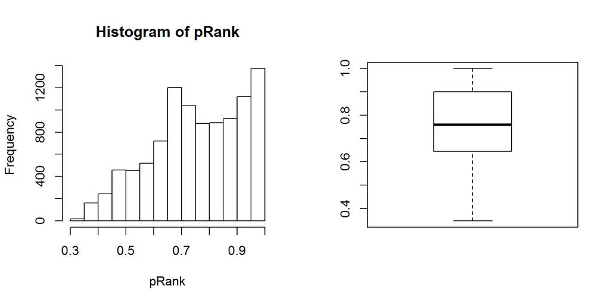

```r
par(mfrow=c(1,2))
hist(pRank)
boxplot(pRank)
```

Using a forward modelling procedure similar to the one Fernandino et al. (2016), we can show that even though binary and decimal number systems use different representational codes, we can decode the identity of the binary pattern of withheld items, based on a forward model of decimal features. Thus, the results fo Fernandino et al. (2016) cannot be used to argue that the GSN uses sensory-motor codes, just because they can decode concept identity with a sensory-motor feature model. This leads to a larger methodological question though - if decoding success based on a specific representational model cannot be used as evidence that the analyzed regions employ that representational code, then what can? This also extends beyond Fernandino et al. (2016) to raising such questions about most decoding fMRI studies.

PS: if we use a k-nearest neighbor regression in the forward model the mean percentile rank becomes 0.998, because knn can fit non-linear relationships between predictors and outcomes. However, I presented the glm model, to show that even it, can produce reliable results in this case).